# Computer Graphics 2024/25 — Lab 1

## Miles Hansard, QMUL.

This lab is an introduction to WebGL programming, based on simple 2D shapes and animations. The objectives are to become familiar with WebGL project structure, drawing operations, and shader syntax.

## Tasks

- Save your output images, **as you go along**, because you will be modifying the code. I provide a `capture` button to do this.
- Zip your code folder, to create `lab-1.zip`, containing **your** final versions of all code files, plus **your** PNG images, in the appropriate directories:

```
A/A1.png ... A/A6.png
B/ ...
etc
```

- Write a short **lab report** to summarize your work, and upload it in **PDF** format. Include each of your output images in the corresponding section **A1, A2, …**, etc, with the summary underneath or alongside. There is a **250 word** limit for each summary (they can be shorter). You may include snippets of code, as well as diagrams and equations, where appropriate. There is a Model answer for task `A0` (which you do not need to include in your report).
- The questions that appear in the tasks are prompts for issues to discuss in the report, in **addition** to your own observations.
- Note that your images might not exactly match the examples. For example, the rotation angle may be different, or you might see minor rendering artefacts (due to driver issues). In particular, you might find that the **line width** cannot be set properly (for reasons explained below). These minor differences do not matter in the marking scheme!
- Please do **not** copy code files or output images from other students. Copied code / images can easily be detected.
- Please do **not** post complete solution code in Teams. If you are really stuck, you may post your attempted solution, for feedback.

## Marking scheme

The lab objectives are listed below. Note that you must achieve all example images, in order to score more than 60. Higher marks are determined by the quality of the report, including content and presentation.

- 0–60: Some example images achieved, with basic descriptions in the report.
- 60–70: All examples achieved, with basic descriptions in the report.
- 70–100: All example images achieved, accompanied by clear and insightful expositions. Correctly formatted report, including links and references where appropriate.

## Setup

Unzip (extract) the file `lab-1.zip`. The folder `lab-1/` contains the following files for exercise `A`:

- `A/rotating-square.html` — markup that runs the code, and shows the result in the browser.
- `A/rotating-square.js` — JavaScript code that defines the scene, and runs the shaders.
- `A/rotating-shape-vert.glsl` — GLSL vertex shader.
- `A/rotating-shape-frag.glsl` — GLSL fragment shader.

Open the four files from directory `A/`, above, in **VS Code**, or your preferred editor. Similar files are provided for exercises `B` and `C`. I strongly advise you to use a **pen and paper** during the labs. It is much easier to debug vertex indexing etc if you draw a sketch of what is supposed to go where…

### Running a local server

Open a terminal in the `lab-1` directory (you can do this with `ctrl'` in Windows VS Code, or `` ctrl` `` in Linux VS code). You may need to use the `cd` command to change directory to `lab-1`. To start a local server, run the following command in the terminal (assuming that Python is installed):

- Linux: `python3 -m http.server`
- Windows: `python -m http.server`
- College PCs: reboot to Linux (recommended), or in Windows: `L:\Anaconda\3.9\python.exe -m http.server`
- Now open this URL, in Firefox: http://localhost:8000/. You should be able to find the HTML files, in directories `A/` `B/`, and `C/`.

### Browser settings

Because we will use a local server, it is **essential** to disable the browser cache (while the dev console is open), so that your shaders can be updated. You only have to do this once; it will be remembered by the browser.

## Exercise A

### A0 — User interaction

- Open the file `rotating-square.html` in **VS Code** and **Firefox**.
- Open the file `rotating-square.js` in **VS Code**.

The `set_speed` function near the top of the JavaScript file is a callback for the HTML speed selection menu. The three possible values in the HTML selection object are `'slow'`, `'medium'`, and `'fast'`. The global variable `theta_step` determines the angular adjustment of the shape, on each frame.

- Check the **console message** (`ctrl-shift-k`) when you change the drop-down selection.
- Complete the body of the `switch` statement, in the `set_speed` function, so that the existing global variable `theta_step` is set to the value `0.005`, `0.01`, or `0.02`, according to the speed value, respectively.
- Add a `Pause` option in the HTML selector, and handle this case in the `switch` statement, using a suitable number for the angle change. This will be useful when you want save the canvas (or if you find the rotation annoying). You can make this the default, by changing the global initialization of `theta_step`.

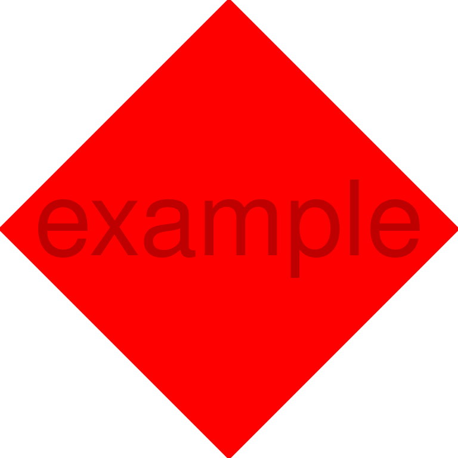

Model answer

### A1 — Modifying the drawing procedure

- Find the line `gl.drawArrays(gl.TRIANGLE_STRIP, 0, num_strip_vertices)` in the JS render function, and change `num_strip_vertices` to `3`. What is the effect of this change, and what does it show about the construction of the square?

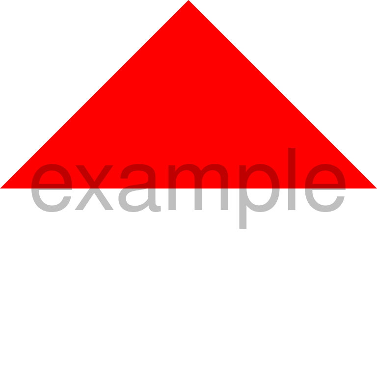

- Undo the above change, so that you see the square again.

### A2 — Modifying the fragment shader

Recall that RGBA colours can be represented by `vec4` types, where the fourth value is the **opacity** (1.0 means opaque). The **fragment shader** `rotating-shape-frag.glsl` colours every fragment red:

```
    gl_FragColor = vec4(1.0, 0.0, 0.0, 1.0);
```

- Change the right-hand side to the RGB vector representation of **blue**, save the file, and reload `rotating-square.html`.
- Define RGB (not RGBA) `vec3` colours for `red` and `green`.
- Add together (using the `+` operator) the RGB vectors for red and green, and turn the result into an opaque RGBA vector `vec4(red + green, 1.0)`.
- Assign the new RGBA vector to `gl_FragColor`, and refresh the display. What do you see?
- Restore the original red colour of the square.

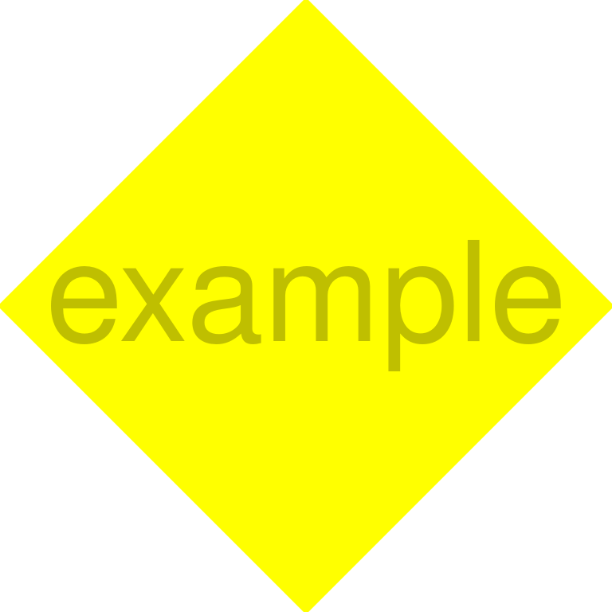

### A3 — Modifying the vertex shader

- Add the following two lines, in the **vertex shader** `rotating-shape-vert.glsl` after the rotation transformation:

```
    gl_Position.x *= (1.0 + s) / 2.0;
    gl_Position.y *= (1.0 + s) / 2.0;
```

- What effect do you see in the animation? Note that `s` represents `sin(theta)`, which is a number in the range `-1...1`. What kind of transformation is performed, by the above lines, on the `(x,y)` position coordinates?

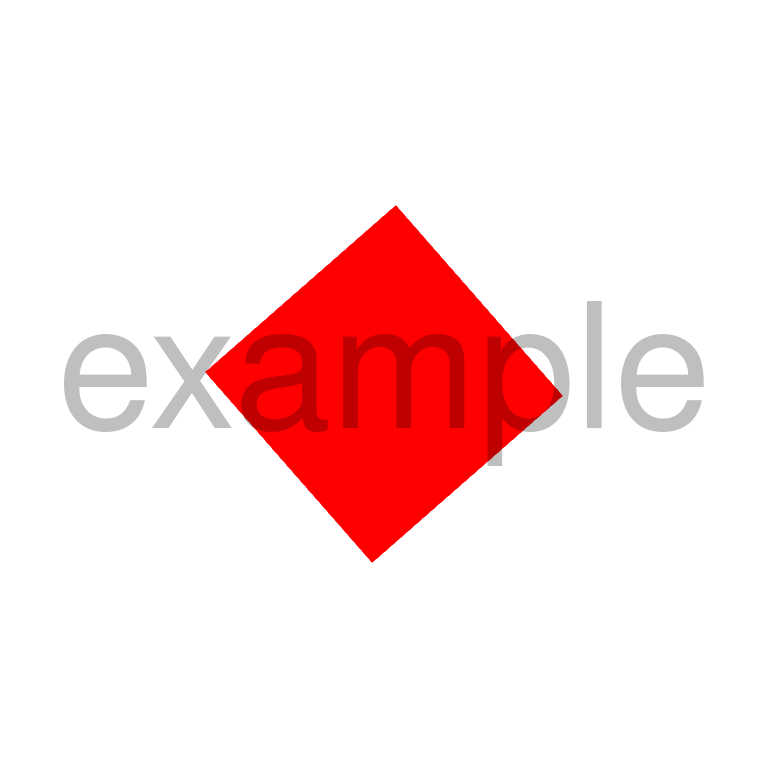

- Remove the two lines, added above, from the vertex shader.

### A4 — Interpolating colours

- Add the following lines, at the top of the **vertex shader** `rotating-shape-vert.glsl`:

```
    attribute vec4 colour;
    varying lowp vec4 colour_var;
```

The first line declares an **attribute** which will be passed in from the JavaScript code. The second line declares a **varying**, which will subsequently be **interpolated** by the fragment shader.

- Add the following line, inside the `main` function of the vertex shader:

```
    colour_var = colour;
```

This means that the current vertex will contribute this colour to the varying interpolation. The surface colour **between** the vertices can then be interpolated by the **fragment** shader, `rotating-shape-frag.glsl`.

- To activate the interpolation, declare the incoming vertex colour as a `varying`, at the top of the fragment shader:

```
    varying lowp vec4 colour_var;
```

- In order to use this variable, change the colour setting in the fragment shader to:

```
    gl_FragColor = colour_var;
```

- Finally, we need to connect the attribute colour data. This has already been prepared in the `init` JavaScript function. In order to enable the attributes, add the following lines to the `render` function, just before the triangles are drawn:

```javascript
    // connect vertex_colour attribute in shader to colour_buf
    gl.vertexAttribPointer(colour_loc, 4, gl.FLOAT, false, 0, 0);
    gl.enableVertexAttribArray(colour_loc);
```

Make sure that you understand these lines, referring to the documentation for vertexAttribPointer and drawArrays.

- You should see something like the following image. Note how the colour has been interpolated across the pixels, based on the four vertex attribute colours.

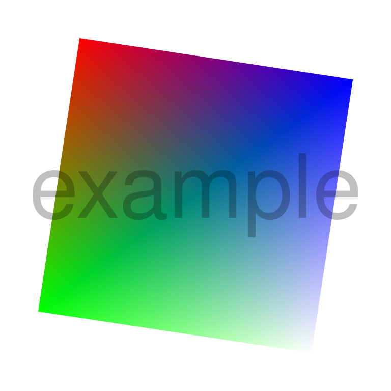

### A5 — Vertex indexing

Note that you might see some small notches in your lines, during these exercises, and you might find that your lines are very thin (which means that the `gl.lineWidth` setting was ignored). Don’t worry: these are driver issues, which won’t affect your marks. *Explanation: there is no universal way to daw high quality lines in 2D and 3D, so OpenGL leaves the [proper implementation](https://mattdesl.svbtle.com/drawing-lines-is-hard) up to the programmer, but we won’t worry about it here*.

- Find the triangle-drawing commands in the JavaScript rendering function:

```javascript
    let num_strip_vertices = vertices.length;
    gl.drawArrays(gl.TRIANGLE_STRIP, 0, num_strip_vertices);
```

```javascript
    gl.vertexAttribPointer(colour_loc, 4, gl.FLOAT, false, 0, 0);
    gl.enableVertexAttribArray(colour_loc);
    let num_line_vertices = indices.length;
    gl.drawElements(gl.LINES, num_line_vertices, gl.UNSIGNED_SHORT, 0);
```

Note the change from direct drawing with `gl.drawArrays` to **indexed** drawing with `gl.drawElements`. Refer to the documentation for drawElements. The `indices` array in the `init` JavaScript function looks like this:

```javascript
    var indices = [
         0, 1
         ];
```

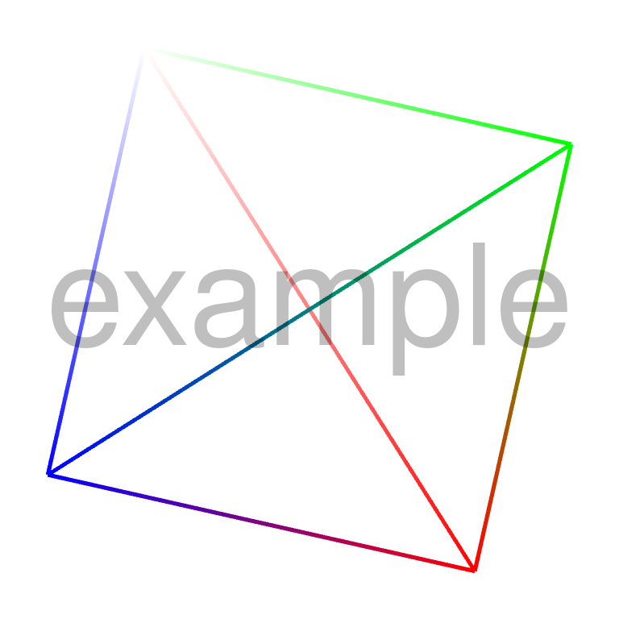

### A6 — Drawing an outline

We can use the same shaders to colour the lines, by adding new RGBA values to the end `colours` array, and telling the shader to start from the appropriate **offset** (instead of starting from the beginning of the array).

```
(number of vertices) * (length of RGBA vec) * (number bytes in Float32)
```

The second and third terms are constant, so this can be expressed in code as:

```javascript
    let black_offset = vertices.length * 4 * 4;
```

- Add this `black_offset` definition to the render function, and change the **last** argument of `gl.vertexAttribPointer` to `black_offset`. You should see the same six lines, but all in black.
- Now **uncomment** the triangle drawing lines, that were commented-out in A5. You should see the following image:

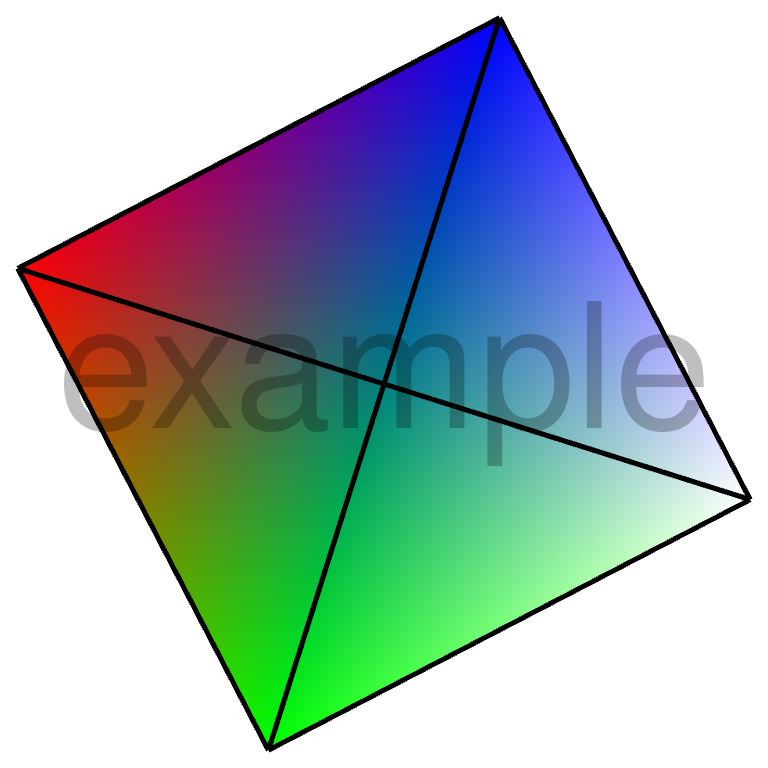

- Think about how we created this image. We used two passes of the **same** shader, but manipulated the **vertex attribute** data in each case.
- The varying colour has been interpolated from the vertex attributes of the two triangles. In fact the line-colours are also interpolated, but they appear constant; why is this?

## Exercise B

Open the file `B/colour-hexagon.js` for editing. The same shaders from exercise A will be used (assuming that exercises A1–A6 have been completed). Copy your shaders into the `B/` directory.

### B1 — Drawing a hexagon

- The vertices of a hexagon are six equally spaced points on the unit circle. Turn the following pseudocode into JS, using a `for` loop, and use it to generate the `vertices[]` array in `colour-hexagon.js`:

```javascript
    num_vertices = 6
    k = 0...num_vertices
    // define an angle that is 0 when k=0 and 2*PI when k=num_vertices
    t = k/num_vertices * 2.0*Math.PI
    // define a point on the circle, at angle t
    P = [ Math.cos(t), Math.sin(t) ]
```

- Also define the `indices[]` array, to work in conjunction with `vertices[]`, bearing in mind that the rendering mode is [gl.LINE_STRIP](https://developer.mozilla.org/en-US/docs/Web/API/WebGL_API/Constants#Rendering_primitives). You should see the outline of a hexagon, like this:

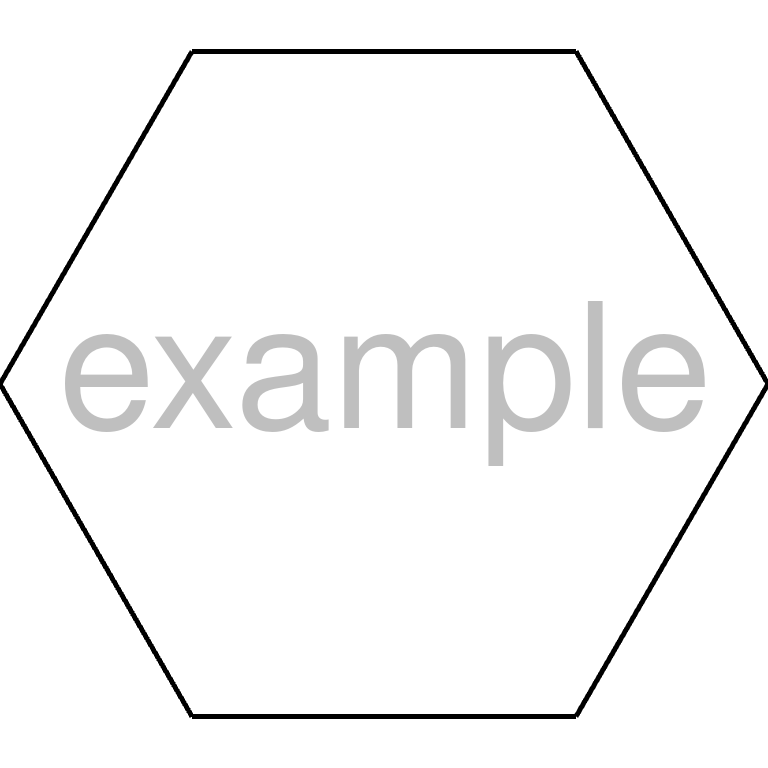

### B2 — Colouring the hexagon

- Next, render a solid hexagon, composed of six triangles. Change the rendering line

```javascript
    gl.drawElements(gl.LINE_STRIP, num_line_vertices, gl.UNSIGNED_SHORT, 0);
```

to use the [TRIANGLE_FAN](https://developer.mozilla.org/en-US/docs/Web/API/WebGL_API/Constants#Rendering_primitives) drawing mode, and modify the `vertices[]` and `indices[]` arrays appropriately (hint: you will need to add an extra vertex).

- Modify the `colours` array, so that the vertices of the hexagon are coloured in the following order, going anticlockwise from the right-most vertex:

```
red, yellow, green, cyan, blue, magenta
```

- The shaders from exercise `A` are used to interpolate the vertex colours across the hexagon. You should see something like this:

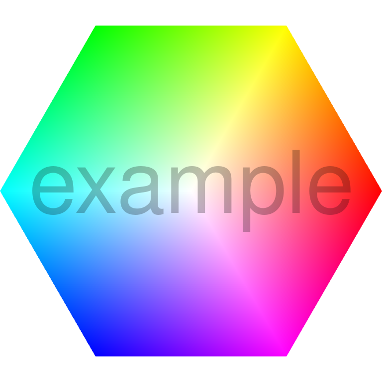

## Exercise C

### C1 — Drawing an octagon

- The file `colour-spiral` contains empty `vertices` and `colours` arrays. Note that these are configured for direct (not indexed) drawing, with `gl.drawArrays`.
- Recall the hexagon code that you wrote in exercise B1. Copy and modify this in the current JS file, to draw an **octagon**. Make use of the pre-defined global variable `num_vertices`, which should be set to 8, for the octagon.
- You should fill the `colours` array, as well as the vertices. For example, you can use `colours.push()` to append an opaque red RGBA array `[1,0,0,1]`, for each vertex that is created in the loop.
- Scale the vertex coordinates by 0.99, so that the result fits nicely in the window (hint `P=[0.99*Math.cos(t),0.99*Math.sin(t)]`).

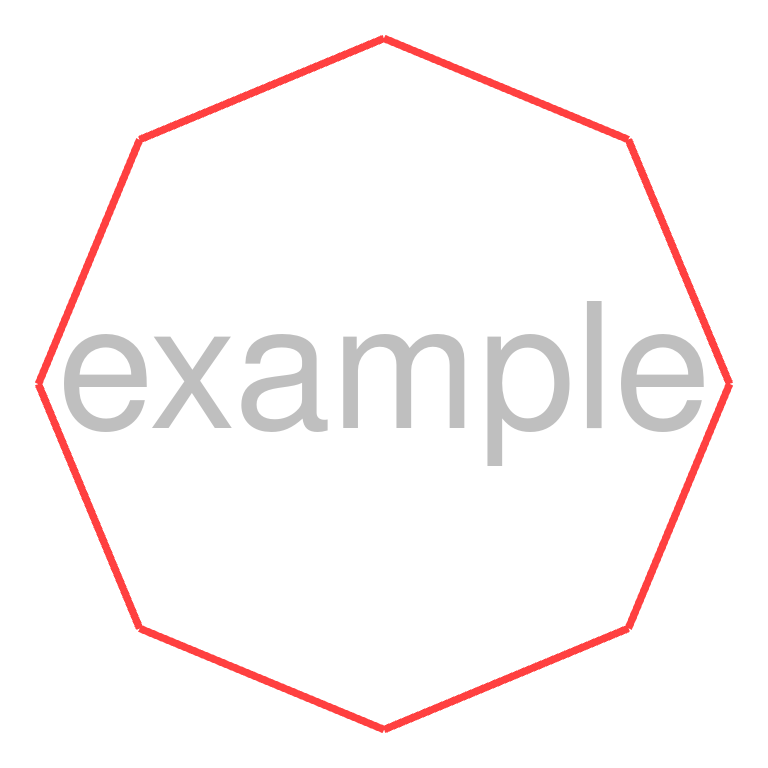

### C2 — Drawing a circle

- Modify your vertex loop to draw a circle, by increasing `num_vertices` to 1000.
- Note that there is no performance cost, even though the rendering task has increased substantially.

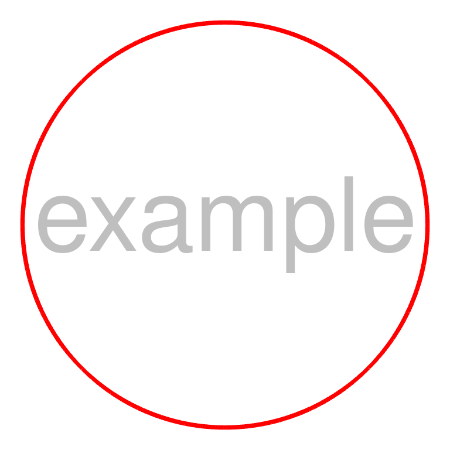

### C3 — Drawing a spiral

- Modify your vertex loop to draw a spiral, with 16 cycles.
- You need a scale parameter `s` that goes from 0 to 1, as `k` goes from 0 to `num_vertices`. You can use this to scale the `[x,y]` coordinates, so that the radius of the path increases from 0 to 1 during the loop (you can multiply by `0.99` if you want to stop the end of the spiral from going outside the canvas).
- The previous angle parameter `t` needs to go **faster**, so that it has covered the angle 16*2π by the end of the loop.

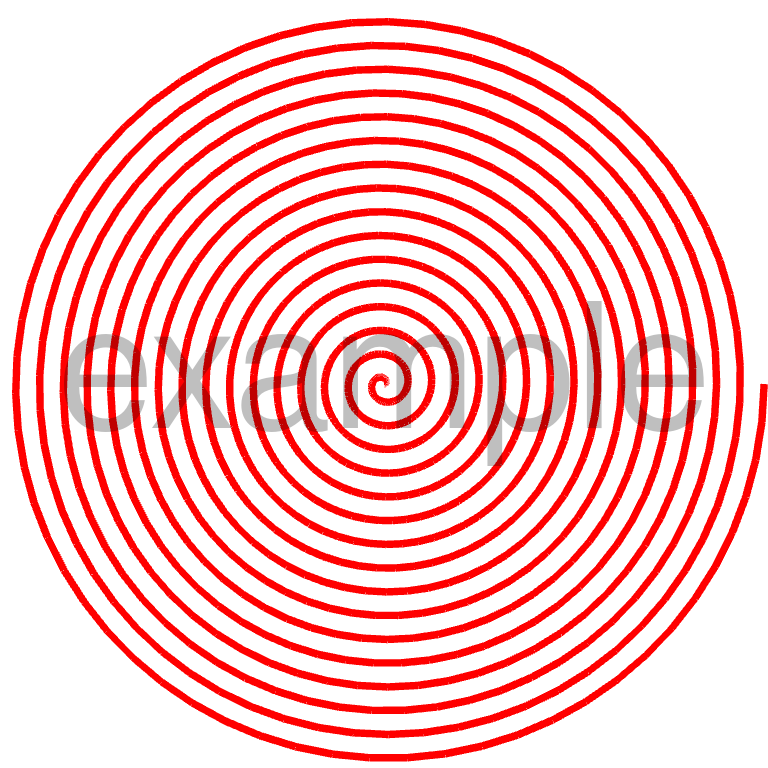

### C4 — Colouring the spiral

- Look for the function `rgba_wheel(t)` in the `shared/graphics.js` JS file. It generates a continuous colour wheel (list of RGBA vectors), from a parameter `t` in the range [0,2π]. It is not necessary to understand the details of the function.
- Use that function to colour the spiral, by calling it with a suitable parameter.

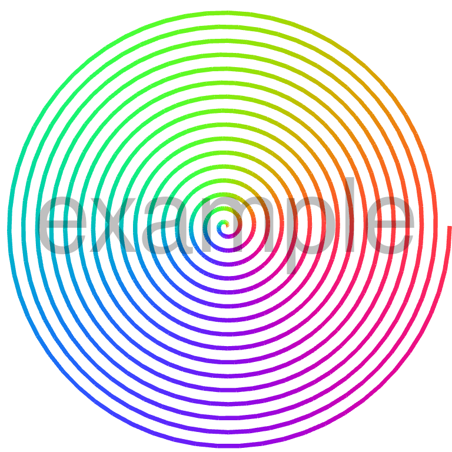

### C5 — Drawing a squiral

- A ‘squircle’ is a shape between a square and a circle. It is a special case of a [superellipse](https://en.wikipedia.org/wiki/Superellipse). Find the **parametric equations**, which are functions of the angular parameter `t`, in the Wikipedia page.
- Write a `squircle(t,n)` function, to implement the following pseudocode (note that the power a<sup>b</sup> is denoted `a^b`), based on the parametric equations. Your function should return a vector `[x,y]` of coordinates on the superellipse.

```javascript
   x(t) = abs(cos(t))^(2/n) * sign(cos(t))
   y(t) = abs(sin(t))^(2/n) * sign(sin(t))
```

- If you keep the previous scale factor `s`, you can draw a square sprial, or ‘squiral’:

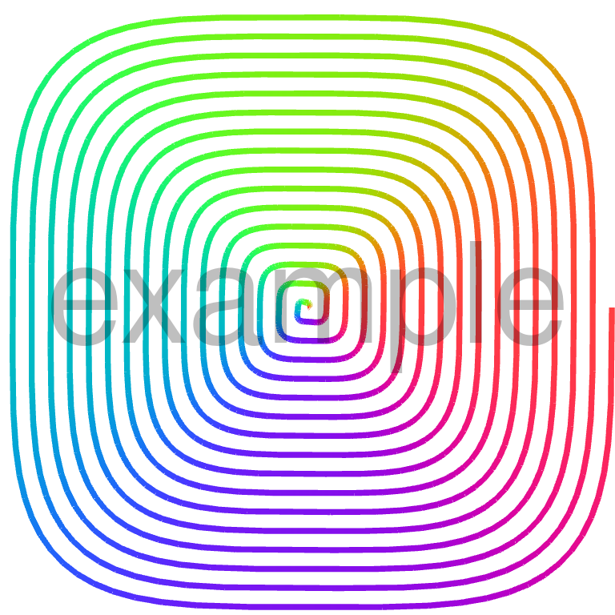

- Try some other settings of the shape parameter `n`, for example: 0.75, 1, 10, 100.

## Exercise D

This is an optional exercise, with **no marks**, but it will be useful for developing your understanding of the attribute buffer syntax.

### D1 — Using interleaved attributes

- Copy the contents of your `C/` directory to a new directory `D/`.
- The separate `vertices[]` and `colours[]` arrays can always be replaced by a **single** attribute array. This is more efficient, and arguably more convenient. Replace the separate array initializations with:

```javascript
    let vertices_colours = [];
```

- Push each `[x,y]` vertex onto the `vertices_colours` array, directly followed by the corresponding `[r,g,b,a]` colour, in the for-loop.
- Re-write the attribute setup functions, using the **single** `vertices_colours` array. Here are some hints:
- The functions `gl.createBuffer()`, `gl.bindBuffer()`, and `gl.bufferData()` will only need to be called **once** each.
- The functions `gl.getAttribLocation()`, `gl.vertexAttribPointer()`, and `gl.enableVertexAttribArray()` will still need to be called **twice** each.
- You will need to work out the **correct arguments** to `gl.vertexAttribPointer()`, using the slides. Note that there are **4** bytes in a 32bit float.
- The resulting image should be the same as before.